# Machine Learning Using Titanic Dataset (Random Forest)

Himansu Sahoo

October 15, 2015

#### Getting the Data into R

```r
train_raw <- read.csv(file="../titanic-train.csv", na.strings=c("", " ", "NA", "NAN"))
test_raw <- read.csv(file="../titanic-test.csv", na.strings=c("", " ", "NA", "NAN"))
# treat all empty values, NAN as NA's
```

In the model, we will use 7 predictors, Survived is the response/target variable.

#### Check the response variable

```r
class(train_raw$Survived) # response variable is an integer
```

```
## [1] "integer"
```

```r
str(train_raw$Survived)
```

```
##  int [1:891] 0 1 1 1 0 0 0 0 1 1 ...
```

```r
summary(train_raw$Survived) # summary() gives five number summary
```

```
##    Min. 1st Qu.  Median    Mean 3rd Qu.    Max.
##  0.0000  0.0000  0.0000  0.3838  1.0000  1.0000
```

```r
table(train_raw$Survived)
```

```
##
##   0   1
## 549 342
```

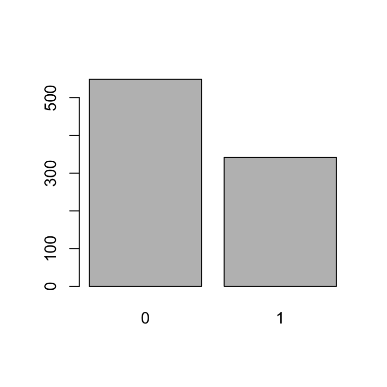

```r
barplot(table(train_raw$Survived))
```

```r
#str(train_raw)
```

First change the response variable to a factor variable.

```r
train_raw$Survived <- as.factor(train_raw$Survived)
class(train_raw$Survived) # Now it is a factor variable
```

```
## [1] "factor"
```

```r
str(train_raw$Survived) # Factor w/ 2 levels "0","1": 1 2 2 2 1 1 1 1 2 2 ...
```

```
##  Factor w/ 2 levels "0","1": 1 2 2 2 1 1 1 1 2 2 ...
```

```r
levels(train_raw$Survived)
```

```
## [1] "0" "1"
```

```r
##summary(train_raw$Survived)
table(train_raw$Survived) # table() is same as summary() for a factor variable
```

```
##
##   0   1
## 549 342
```

```r
prop.table(table(train_raw$Survived))
```

```
##
##         0         1
## 0.6161616 0.3838384
```

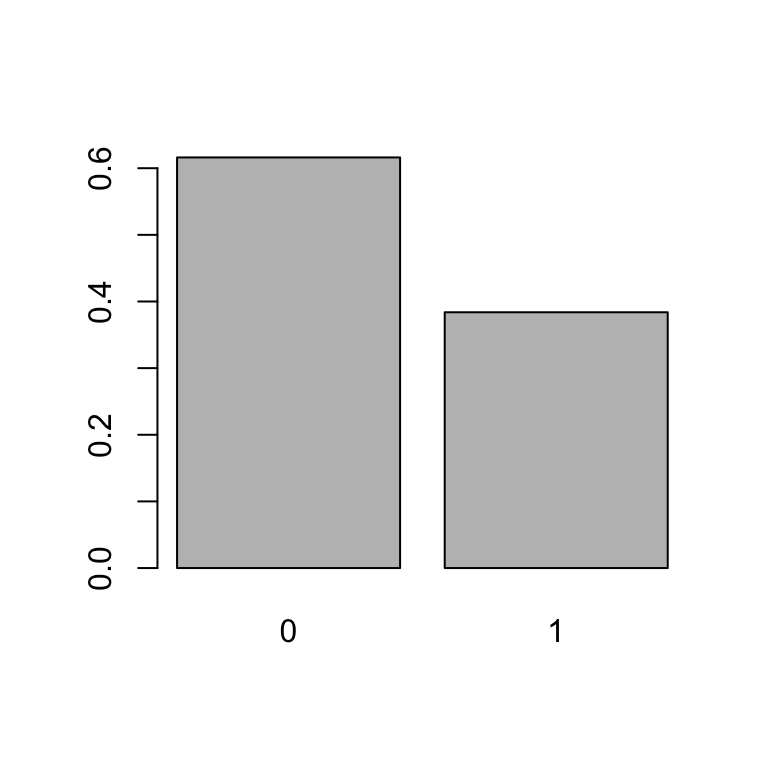

```r
#barplot(table(train_raw$Survived))
barplot(prop.table(table(train_raw$Survived)))
```

```r
#str(train_raw)
```

#### Step 1 : Data cleaning (train data)

```r
#names(train_raw)
cat("train_raw : dimension :  ", dim(train_raw) , "\n")
```

```
## train_raw : dimension :   891 12
```

```r
func_ratioNA <- function(x) length(x[x==""])/length(x)
remove_trainvar <- names(train_raw) %in% c("PassengerId", "Name", "Ticket", "Cabin")
train_final <- train_raw[, !remove_trainvar]
#names(train_final) # "PassengerId", "Name", "Ticket", "Cabin" are removed
cat("train_final : dimension :  ", dim(train_final) , "\n")
```

```
## train_final : dimension :   891 8
```

```r
apply(train_final, 2, FUN = func_ratioNA)
```

```
##    Survived      Pclass         Sex         Age       SibSp       Parch
## 0.000000000 0.000000000 0.000000000 0.198653199 0.000000000 0.000000000
##        Fare    Embarked
## 0.000000000 0.002244669
```

Age and Embarked have missing values.

#### Step 2 : Data cleaning (test data)

```r
cat("test_raw : dimension :  ", dim(test_raw) , "\n")
```

```
## test_raw : dimension :   418 11
```

```r
remove_testvar <- names(test_raw) %in% c("PassengerId", "Name", "Ticket", "Cabin")
test_final <- test_raw[, !remove_testvar]
cat("test_final : dimension :  ", dim(test_final) , "\n")
```

```
## test_final : dimension :   418 7
```

```r
apply(test_final, 2, FUN = func_ratioNA)
```

```
##      Pclass         Sex         Age       SibSp       Parch        Fare
## 0.000000000 0.000000000 0.205741627 0.000000000 0.000000000 0.002392344
##    Embarked
## 0.000000000
```

Age and Fare have missing values. The response variable Survived is missing in the test data.

### Step 3 : Fitting Random Forest Model

We will use the `caret` package in R to build the `randomForest` model with **method=rf**.

#### Splitting data into a training and validation set

We will use the `createDataPartition` function to split the `train\_final` dataset into 70% train_set and 30% valid_set. Set seed in the beginning to reproduce the same result in future.

Random forest will not work in case of NA’s. The response variable should be categorical with 2 levels. In order to avoid the problem, we changed earlier the response variable from integer to a factor variable with 2 levels. Now lets treat the missing values. Age and Embarked has missing values in the training set. Replace Age by -1 and Embarked by the highest category.

```r
colSums(is.na(train_final))
```

```
## Survived   Pclass      Sex      Age    SibSp    Parch     Fare Embarked
##        0        0        0      177        0        0        0        2
```

```r
train_final$Age[is.na(train_final$Age)] <- -1
train_final$Embarked[is.na(train_final$Embarked)] <- "S"  # Embarked has 2 missing values
colSums(is.na(train_final))
```

```
## Survived   Pclass      Sex      Age    SibSp    Parch     Fare Embarked
##        0        0        0        0        0        0        0        0
```

```r
#str(train_final)
library(caret)  # this also calls the rpart
set.seed(1099)
inTrain <- createDataPartition(y=train_final$Survived, p=0.70, list=FALSE)
train_set <- train_final[inTrain,]
valid_set <- train_final[-inTrain,]
```

```r
set.seed(1099)
rf_model <- train(Survived~., method="rf", data=train_set)
```

[output not shown]

[output not shown]

The response variable is integer with only two value 0 and 1 (less than five unique values). Thats why the model thinks the problem as regression. To avoid this problem, we changed earlier the response variable to a factor variable with 2 levels.

#### print some parameters of the model

```r
class(rf_model)  # output is "train"         "train.formula"
```

```
## [1] "train"         "train.formula"
```

```r
print(rf_model) # str(), summary() will give rubbish
```

```
## Random Forest
##
## 625 samples
##   7 predictor
##   2 classes: '0', '1'
##
## No pre-processing
## Resampling: Bootstrapped (25 reps)
## Summary of sample sizes: 625, 625, 625, 625, 625, 625, ...
## Resampling results across tuning parameters:
##
##   mtry  Accuracy   Kappa      Accuracy SD  Kappa SD
##   2     0.8167314  0.5969322  0.02603340   0.05298151
##   5     0.7995588  0.5687547  0.02793526   0.05514684
##   8     0.7882523  0.5453192  0.02280222   0.04648031
##
## Accuracy was used to select the optimal model using  the largest value.
## The final value used for the model was mtry = 2.
```

```r
names(rf_model)
```

```
##  [1] "method"       "modelInfo"    "modelType"    "results"
##  [5] "pred"         "bestTune"     "call"         "dots"
##  [9] "metric"       "control"      "finalModel"   "preProcess"
## [13] "trainingData" "resample"     "resampledCM"  "perfNames"
## [17] "maximize"     "yLimits"      "times"        "terms"
## [21] "coefnames"    "contrasts"    "xlevels"
```

```r
ls(rf_model) # ls() is same as names() except it gives an alphabateical list
```

```
##  [1] "bestTune"     "call"         "coefnames"    "contrasts"
##  [5] "control"      "dots"         "finalModel"   "maximize"
##  [9] "method"       "metric"       "modelInfo"    "modelType"
## [13] "perfNames"    "pred"         "preProcess"   "resample"
## [17] "resampledCM"  "results"      "terms"        "times"
## [21] "trainingData" "xlevels"      "yLimits"
```

```r
rf_model$method
```

```
## [1] "rf"
```

```r
rf_model$modelType
```

```
## [1] "Classification"
```

```r
rf_model$results
```

```
##   mtry  Accuracy     Kappa AccuracySD    KappaSD
## 1    2 0.8167314 0.5969322 0.02603340 0.05298151
## 2    5 0.7995588 0.5687547 0.02793526 0.05514684
## 3    8 0.7882523 0.5453192 0.02280222 0.04648031
```

```r
rf_model$bestTune
```

```
##   mtry
## 1    2
```

```r
rf_model$metric
```

```
## [1] "Accuracy"
```

```r
rf_model$finalModel # the output is randomForest
```

```
##
## Call:
##  randomForest(x = x, y = y, mtry = param$mtry)
##                Type of random forest: classification
##                      Number of trees: 500
## No. of variables tried at each split: 2
##
##         OOB estimate of  error rate: 17.12%
## Confusion matrix:
##     0   1 class.error
## 0 354  31  0.08051948
## 1  76 164  0.31666667
```

```r
rf_model$perfNames
```

```
## [1] "Accuracy" "Kappa"
```

```r
rf_model$coefnames
```

```
## [1] "Pclass"    "Sexmale"   "Age"       "SibSp"     "Parch"     "Fare"
## [7] "EmbarkedQ" "EmbarkedS"
```

```r
rf_model$xlevels
```

```
## $Sex
## [1] "female" "male"
##
## $Embarked
## [1] "C" "Q" "S"
```

#### variable importance

```r
rf_imp <- varImp(rf_model, scale=FALSE)
rf_imp # sorts in decreasing order, class is varImp.train
```

```
## rf variable importance
##
##           Overall
## Sexmale    64.054
## Fare       42.784
## Age        30.675
## Pclass     23.336
## SibSp      11.006
## Parch      10.617
## EmbarkedS   8.144
## EmbarkedQ   2.445
```

```r
# by default varImp returns scaled results in the range 0-100
#class(rf_model$finalModel) # class is a randomForest object
#varImp(rf_model$finalModel) # class is a dataframe
#round(importance(rf_model$finalModel), 2) # only works with randomForest object, class is a matrix
```

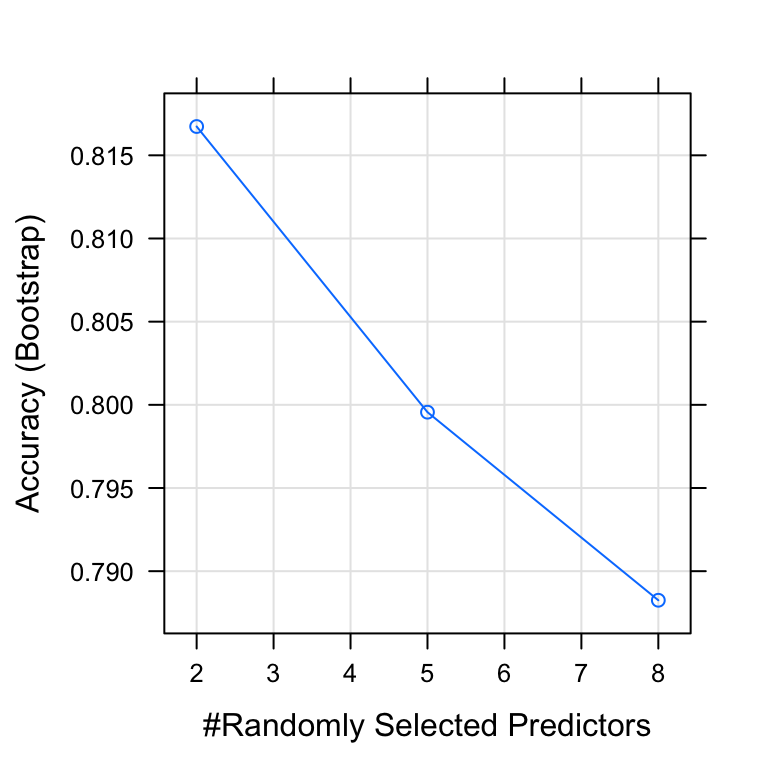

```r
plot(rf_model) # plot of Accuracy vrs. selected predictors
```

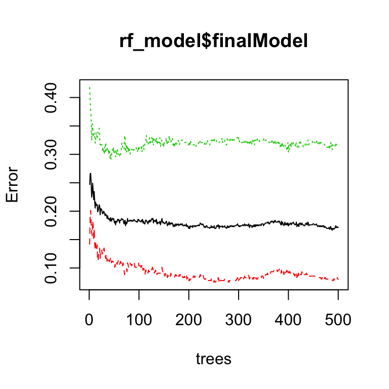

```r
plot(rf_model$finalModel) # Error vrs. no of trees
```

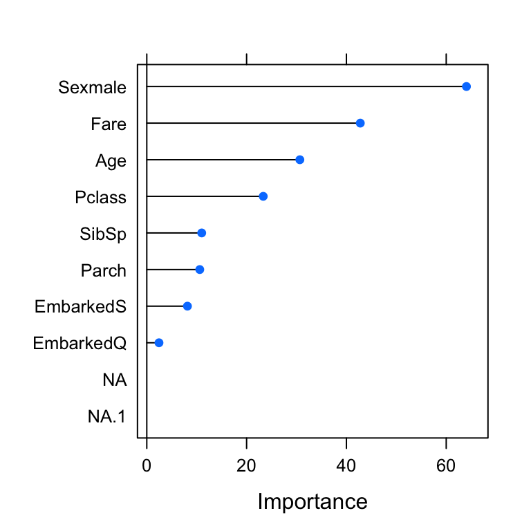

```r
plot(rf_imp, top=10) # top 10 most important variables
```

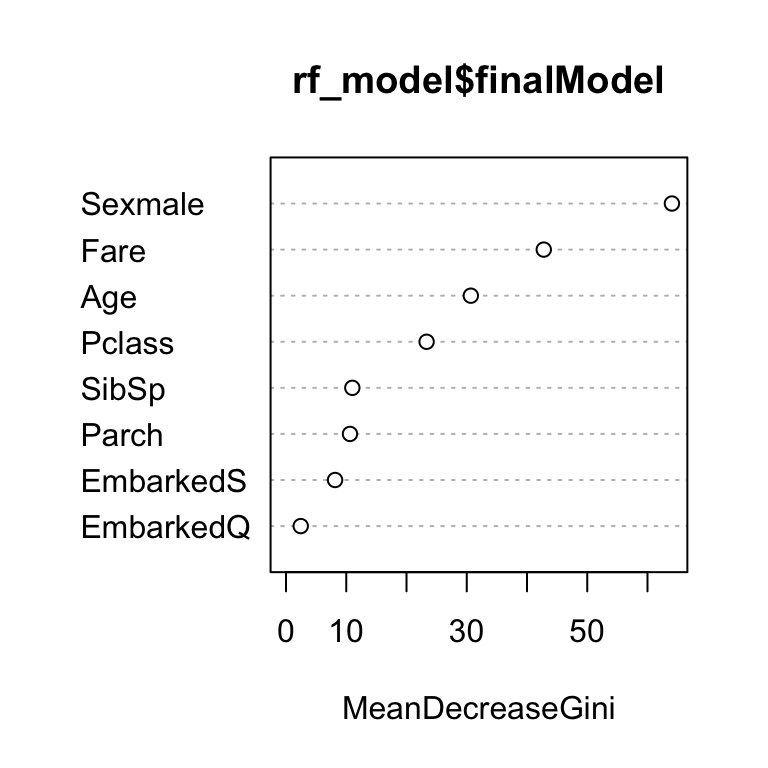

```r
varImpPlot(rf_model$finalModel) # this will only work for a randomForest object
```

#### apply RF model on 70% train set

###### confusion matrix using the finalModel

```r
table(train_set$Survived)
```

```
##
##   0   1
## 385 240
```

```r
#predict(rf_model) # this give error, needs a newdata argument
rf_pred_final <- predict(rf_model$finalModel) # the output is a factor variable
table(rf_pred_final)
```

```
## rf_pred_final
##   0   1
## 430 195
```

```r
confusionMatrix(rf_pred_final, train_set$Survived)
```

```
## Confusion Matrix and Statistics
##
##           Reference
## Prediction   0   1
##          0 354  76
##          1  31 164
##
##                Accuracy : 0.8288
##                  95% CI : (0.7969, 0.8575)
##     No Information Rate : 0.616
##     P-Value [Acc > NIR] : < 2.2e-16
##
##                   Kappa : 0.6249
##  Mcnemar's Test P-Value : 2.103e-05
##
##             Sensitivity : 0.9195
##             Specificity : 0.6833
##          Pos Pred Value : 0.8233
##          Neg Pred Value : 0.8410
##              Prevalence : 0.6160
##          Detection Rate : 0.5664
##    Detection Prevalence : 0.6880
##       Balanced Accuracy : 0.8014
##
##        'Positive' Class : 0
##
```

[output not shown]

###### apply the rf_model on the train_set

```r
table(train_set$Survived)
```

```
##
##   0   1
## 385 240
```

```r
train_rf_predict <- predict(rf_model, newdata=train_set)
table(train_rf_predict)
```

```
## train_rf_predict
##   0   1
## 422 203
```

```r
confusionMatrix(train_rf_predict, train_set$Survived)
```

```
## Confusion Matrix and Statistics
##
##           Reference
## Prediction   0   1
##          0 374  48
##          1  11 192
##
##                Accuracy : 0.9056
##                  95% CI : (0.8799, 0.9274)
##     No Information Rate : 0.616
##     P-Value [Acc > NIR] : < 2.2e-16
##
##                   Kappa : 0.7945
##  Mcnemar's Test P-Value : 2.775e-06
##
##             Sensitivity : 0.9714
##             Specificity : 0.8000
##          Pos Pred Value : 0.8863
##          Neg Pred Value : 0.9458
##              Prevalence : 0.6160
##          Detection Rate : 0.5984
##    Detection Prevalence : 0.6752
##       Balanced Accuracy : 0.8857
##
##        'Positive' Class : 0
##
```

Do the missing values treatment, otherwise the confusion matrix will give problem. Train function will be fine.

```
ERROR : Error in table(data, reference, dnn = dnn, ...) :
  all arguments must have the same length
```

#### apply the rf_model on 30% valid_set

```r
table(valid_set$Survived)
```

```
##
##   0   1
## 164 102
```

```r
valid_rf_predict <- predict(rf_model, newdata=valid_set)
table(valid_rf_predict)
```

```
## valid_rf_predict
##   0   1
## 173  93
```

```r
confusionMatrix(valid_rf_predict, valid_set$Survived)
```

```
## Confusion Matrix and Statistics
##
##           Reference
## Prediction   0   1
##          0 142  31
##          1  22  71
##
##                Accuracy : 0.8008
##                  95% CI : (0.7476, 0.847)
##     No Information Rate : 0.6165
##     P-Value [Acc > NIR] : 7.74e-11
##
##                   Kappa : 0.5715
##  Mcnemar's Test P-Value : 0.2718
##
##             Sensitivity : 0.8659
##             Specificity : 0.6961
##          Pos Pred Value : 0.8208
##          Neg Pred Value : 0.7634
##              Prevalence : 0.6165
##          Detection Rate : 0.5338
##    Detection Prevalence : 0.6504
##       Balanced Accuracy : 0.7810
##
##        'Positive' Class : 0
##
```

## Calculate ROC Curve (using pROC package)

```
Error in train.default(x, y, weights = w, ...) :
  At least one of the class levels is not a valid R variable name; This will cause errors when class probabilities are generated because the variables names will be converted to  X0, X1 . Please use factor levels that can be used as valid R variable names  (see ?make.names for help).
```

```r
levels(train_final$Survived)[levels(train_final$Survived)=="0"] <- "No"
levels(train_final$Survived)[levels(train_final$Survived)=="1"] <- "Yes"
levels(train_final$Survived)
```

```
## [1] "No"  "Yes"
```

```r
library(caret)  # this also calls the rpart
set.seed(1099)
inTrain <- createDataPartition(y=train_final$Survived, p=0.70, list=FALSE)
train_set <- train_final[inTrain,]
valid_set <- train_final[-inTrain,]

set.seed(1099)
rf_roc_model <- train(Survived~., method="rf", data=train_set, metric="ROC", trControl=trainControl(summaryFunction=twoClassSummary, classProbs=TRUE))
print(rf_roc_model)
```

```
## Random Forest
##
## 625 samples
##   7 predictor
##   2 classes: 'No', 'Yes'
##
## No pre-processing
## Resampling: Bootstrapped (25 reps)
## Summary of sample sizes: 625, 625, 625, 625, 625, 625, ...
## Resampling results across tuning parameters:
##
##   mtry  ROC        Sens       Spec       ROC SD      Sens SD
##   2     0.8652513  0.9058585  0.6724300  0.01892106  0.03022661
##   5     0.8523336  0.8590835  0.7033671  0.01980808  0.03107697
##   8     0.8429723  0.8455868  0.6944235  0.02155728  0.03136619
##   Spec SD
##   0.04709680
##   0.04958113
##   0.05382095
##
## ROC was used to select the optimal model using  the largest value.
## The final value used for the model was mtry = 2.
```

```r
print(rf_roc_model$finalModel)
```

```
##
## Call:
##  randomForest(x = x, y = y, mtry = param$mtry)
##                Type of random forest: classification
##                      Number of trees: 500
## No. of variables tried at each split: 2
##
##         OOB estimate of  error rate: 16.96%
## Confusion matrix:
##      No Yes class.error
## No  352  33  0.08571429
## Yes  73 167  0.30416667
```

```r
predict_valid_rf_roc <- predict(rf_roc_model, newdata=valid_set, type="prob")
# the output is a data frame with two columns No and Yes
```

```r
# give an response variable and a prediction output from RF model
library(pROC)
```

```r
roc_curve <- roc(response = valid_set$Survived, predictor = predict_valid_rf_roc$Yes)
print(roc_curve)
```

```
##
## Call:
## roc.default(response = valid_set$Survived, predictor = predict_valid_rf_roc$Yes)
##
## Data: predict_valid_rf_roc$Yes in 164 controls (valid_set$Survived No) < 102 cases (valid_set$Survived Yes).
## Area under the curve: 0.861
```

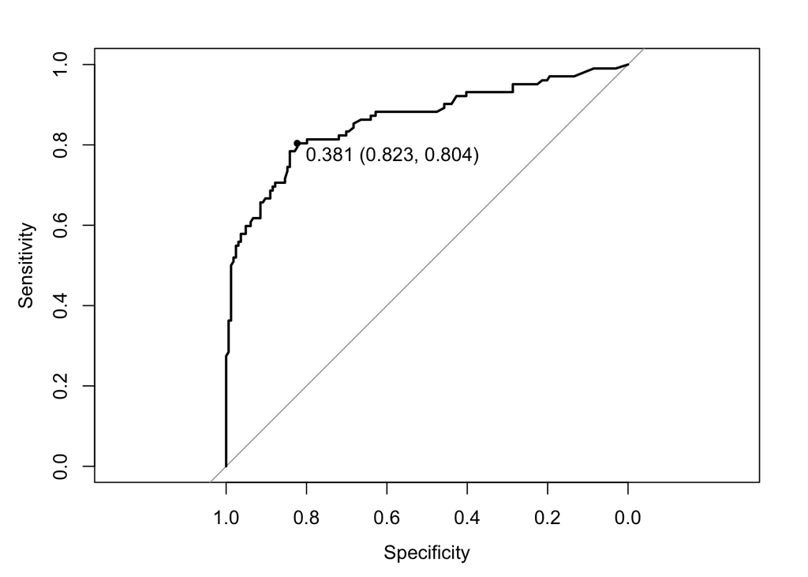

[output not shown]

```r
plot(roc_curve, print.thres="best", print.thres.best.method="closest.topleft")
```

```r
roc_result <- coords(roc_curve, "best", best.method="closest.topleft", ret=c("threshold", "accuracy"))
print(roc_result)
```

```
## threshold  accuracy
## 0.3810000 0.8157895
```

## Calculate ROC Curve (using ROCR package)

```r
library(ROCR)
```

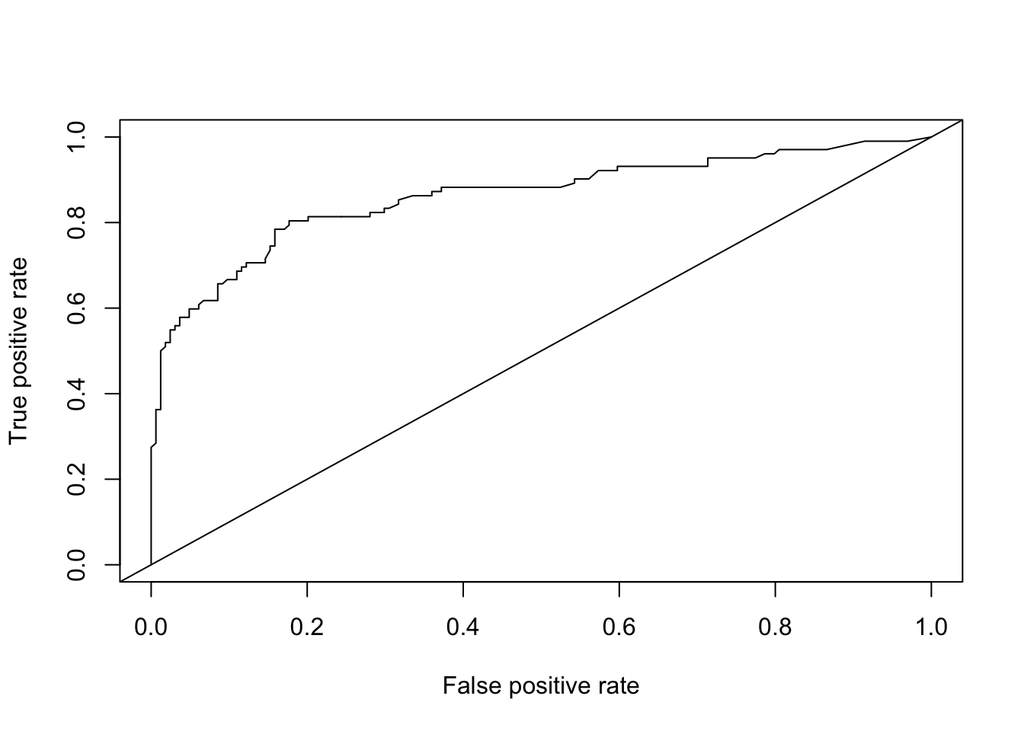

```r
pred <- prediction(predict_valid_rf_roc$Yes, valid_set$Survived)
perf <- performance(pred, measure="tpr", x.measure="fpr")
plot(perf)
abline(a=0, b=1)
```

```r
auc <- performance(pred, measure = "auc")
# print the AUC value (Area Under the Curve)
print(auc@y.values)
```

```
## [[1]]
## [1] 0.8609816
```